# Analysis of Breast Tumor Tissue Biopsies Using PCA

# Correlation between variables

To study the correlation between the variables used for tumor classification, we need to create a correlation matrix. To do this, we create a subset from **biopsy** that contains exclusively the data for the variables of interest (V1 to V9), removing the ID column. We will name this new dataframe **biopsy_vars**, as it only contains the mentioned variables.

```r
biopsy_vars <- biopsy[, -c(1, 11)]
str(biopsy_vars)
```

```
## 'data.frame':    683 obs. of  9 variables:
##  $ V1: int  5 5 3 6 4 8 1 2 2 4 ...
##  $ V2: int  1 4 1 8 1 10 1 1 1 2 ...
##  $ V3: int  1 4 1 8 1 10 1 2 1 1 ...
##  $ V4: int  1 5 1 1 3 8 1 1 1 1 ...
##  $ V5: int  2 7 2 3 2 7 2 2 2 2 ...
##  $ V6: int  1 10 2 4 1 10 10 1 1 1 ...
##  $ V7: int  3 3 3 3 3 9 3 3 1 2 ...
##  $ V8: int  1 2 1 7 1 7 1 1 1 1 ...
##  $ V9: int  1 1 1 1 1 1 1 1 5 1 ...
```

Now we create the correlation matrix using R’s cor function. We will store it in **biopsy_vars_cor**.

```r
biopsy_vars_cor <- cor(biopsy_vars)
print(biopsy_vars_cor)
```

```
##           V1        V2        V3        V4        V5        V6        V7
## V1 1.0000000 0.6424815 0.6534700 0.4878287 0.5235960 0.5930914 0.5537424
## V2 0.6424815 1.0000000 0.9072282 0.7069770 0.7535440 0.6917088 0.7555592
## V3 0.6534700 0.9072282 1.0000000 0.6859481 0.7224624 0.7138775 0.7353435
## V4 0.4878287 0.7069770 0.6859481 1.0000000 0.5945478 0.6706483 0.6685671
## V5 0.5235960 0.7535440 0.7224624 0.5945478 1.0000000 0.5857161 0.6181279
## V6 0.5930914 0.6917088 0.7138775 0.6706483 0.5857161 1.0000000 0.6806149
## V7 0.5537424 0.7555592 0.7353435 0.6685671 0.6181279 0.6806149 1.0000000
## V8 0.5340659 0.7193460 0.7179634 0.6031211 0.6289264 0.5842802 0.6656015
## V9 0.3509572 0.4607547 0.4412576 0.4188983 0.4805833 0.3392104 0.3460109
##           V8        V9
## V1 0.5340659 0.3509572
## V2 0.7193460 0.4607547
## V3 0.7179634 0.4412576
## V4 0.6031211 0.4188983
## V5 0.6289264 0.4805833
## V6 0.5842802 0.3392104
## V7 0.6656015 0.3460109
## V8 1.0000000 0.4337573
## V9 0.4337573 1.0000000
```

We create the significance matrix with the p-values obtained from the **correlation matrix** calculation. To do this, we use the R function **cor.mtest** (in this case, with a 0.95 confidence level).

```r
biopsy_vars_sig <- cor.mtest(biopsy_vars, conf.level = 0.95)
print(biopsy_vars_sig$p)
```

```
##              V1            V2            V3            V4            V5
## V1 0.000000e+00  8.964173e-81  2.064616e-84  4.027956e-42  2.411759e-49
## V2 8.964173e-81  0.000000e+00 2.567742e-258 1.544338e-104 3.535863e-126
## V3 2.064616e-84 2.567742e-258  0.000000e+00  4.146228e-96 3.061101e-111
## V4 4.027956e-42 1.544338e-104  4.146228e-96  0.000000e+00  1.627087e-66
## V5 2.411759e-49 3.535863e-126 3.061101e-111  1.627087e-66  0.000000e+00
## V6 4.050902e-66  2.402961e-98 1.807287e-107  2.058229e-90  3.828707e-64
## V7 3.880813e-56 3.184894e-127 3.567289e-117  1.153511e-89  3.199163e-73
## V8 1.260114e-51 7.433029e-110 3.018221e-109  6.883291e-69  1.734754e-76
## V9 3.148289e-21  3.398097e-37  6.531371e-34  2.125287e-30  9.266128e-41
##               V6            V7            V8           V9
## V1  4.050902e-66  3.880813e-56  1.260114e-51 3.148289e-21
## V2  2.402961e-98 3.184894e-127 7.433029e-110 3.398097e-37
## V3 1.807287e-107 3.567289e-117 3.018221e-109 6.531371e-34
## V4  2.058229e-90  1.153511e-89  6.883291e-69 2.125287e-30
## V5  3.828707e-64  3.199163e-73  1.734754e-76 9.266128e-41
## V6  0.000000e+00  4.391890e-94  9.158074e-64 7.473326e-20
## V7  4.391890e-94  0.000000e+00  1.312645e-88 1.214400e-20
## V8  9.158074e-64  1.312645e-88  0.000000e+00 1.053441e-32
## V9  7.473326e-20  1.214400e-20  1.053441e-32 0.000000e+00
```

Using the **corrplot** function, we create a **correlation plot**. Here, we can see that the most correlated variables (r = 0.91) are **V2** and **V3** (cell size and shape uniformity, respectively). Several variables are correlated with r values close to 0.8. All r values obtained in the matrix are positive (+) and significant with a 95% confidence level. **The use of the corrplot function requires the installation of the corrplot library, as it is not included by default in R**.

[Note] PCA helps simplify the analysis by reducing the number of variables while preserving most of the variance or relevant information in the data. This is particularly useful when the variables are highly correlated, as PCA can identify principal components that capture the underlying relationships between variables and reduce redundancy. Additionally, it makes interpretation easier by reducing the number of individual variables to consider.

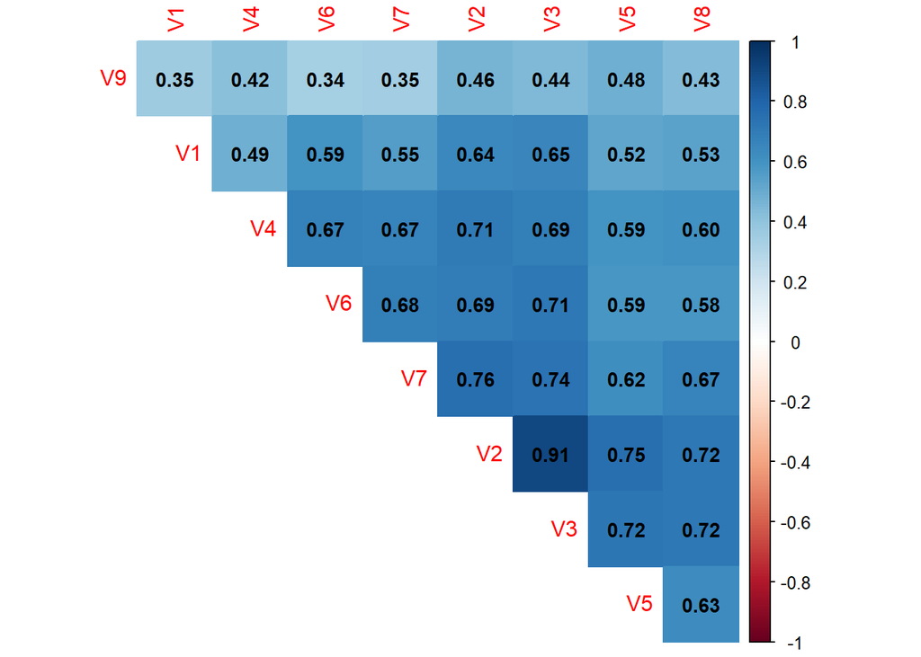

```r
corrplot(biopsy_vars_cor,
         p.mat = biopsy_vars_sig$p, sig.level = 0.05,
         method = "color",
         order = "hclust",
         type = "upper",
         diag = FALSE,
         addCoef.col = "black",
         number.cex = 0.9)
```

# PCA

The **prcomp** function in R is used to perform Principal Component Analysis (PCA). In this case, **center = TRUE** ensures that the variables are centered around zero mean, eliminating the bias introduced by different variable means, and **scale = TRUE** normalizes the variables to have unit variance, ensuring that all variables contribute equally to the analysis, regardless of their original scales.

```r
biopsy_PCA <- prcomp(biopsy_vars, center = TRUE, scale = TRUE)
```

We can use **prcomp** on the original dataframe **biopsy** (where we did not remove the ID variable of type char). In this case, it is necessary to specify the columns/variables that will be considered in the analysis. biopsy_PCA <- prcomp(biopsy[,-c(1,11)], center = TRUE, scale = TRUE)

### Scree plot

A **Scree Plot** is a graph that shows the variance explained by each principal component in PCA. The x-axis represents the principal components (sorted according to the amount of variance they explain), and the y-axis shows the variance explained by each component.

In the plot, the ‘elbow’ or inflection point is of particular importance. It is where the slope of the graph changes significantly. By observing this, we can determine the number of principal components that explain a significant amount of variance.

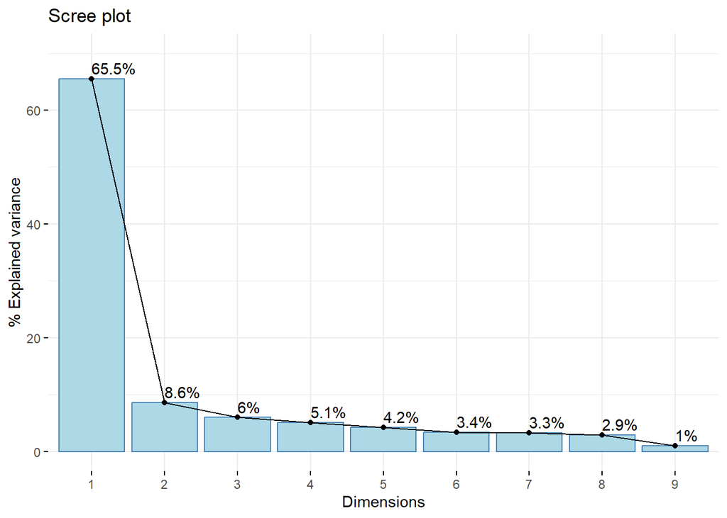

```r
scree_plot <- fviz_screeplot(biopsy_PCA,
                             title = "Scree plot",
                             xlab = "Dimensions",
                             ylab = "% Explained variance",
                             barfill = "lightblue",
                             ylim = c(0, 70),
                             addlabels = TRUE)
scree_plot
```

In PCA, the first components capture the majority of the variability in the data. In this specific case, our first component explains the largest portion of the variance (65.5%), while the second explains a smaller proportion (8.6%). **These two components together explain 74.1% of the total variance**. The significant difference between the first and second components indicates that the first is clearly more significant for describing the structure of the data we are analyzing. However, the second component may also be useful for informational purposes. This is something we will explore further as we delve into the results obtained from the PCA.

### Contribution of the variables

In the context of PCA, the **contribution of the variables** refers to how much each original variable contributes to a specific principal component. This concept is key to understanding how the original variables combine to form the principal components, as well as interpreting the importance of each variable in the reduced data space representation.

By taking a closer look, we might draw some conclusions.

In order, the variables that contribute the most are: **V2** (uniformity of cell size): **Uniformity of cell size**.  
**V3** (uniformity of cell shape): **Uniformity of cell shape**.  
**V7** (bland chromatin): **Bland chromatin**.  
**V5** (single epithelial cell size): Size of individual epithelial cells.  
**V8** (normal nucleoli): Normal nucleoli.  
**V6** (bare nuclei): Presence of bare nuclei.

The red line represents a threshold indicating the value of contribution **above which variables are considered significant for the principal component we are analyzing**.

**The first principal component would be closely associated with characteristics related to the morphology and size of the breast tissue cells**.

Furthermore, the relationship between **bland chromatin (V7)** and the morphological characteristics of cells, including their size and shape, is supported by scientific research in cell biology and cancer. There is evidence linking bland chromatin with breast cancer due to its influence on DNA accessibility and gene expression regulation (in this case, increased transcriptional activity). Alterations in the structure and epigenetic modifications of chromatin can facilitate the activation of genes associated with malignancy and contribute to tumor progression.

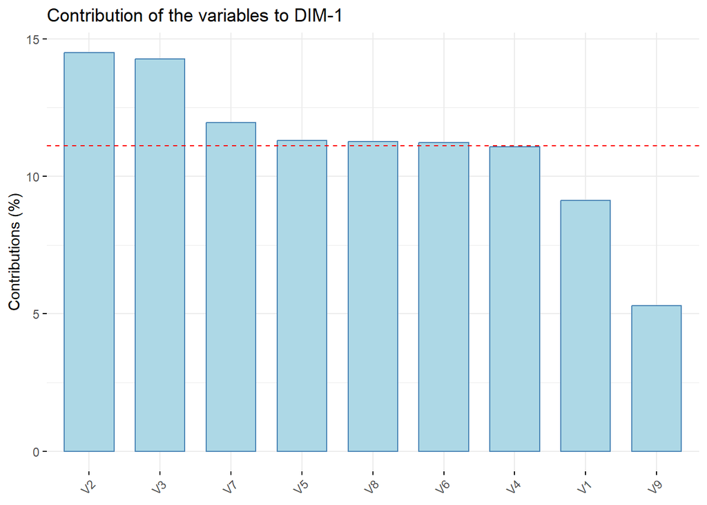

```r
contrib_plot_dim1 <- fviz_contrib(biopsy_PCA,
                               choice = "var",
                               axes = 1,
                               fill = "lightblue")

contrib_plot_dim1 +
  ggtitle("Contribution of the variables to DIM-1") +
  ylab("Contributions (%)")
```

In the case of the **second principal component**, we have a clear dominance of a single variable:

**V9** (mitoses): Number of mitoses.

This second component would reflect **cellular activity in terms of proliferation**. Tissue samples with non-cancerous cells would show normal mitosis rates, whereas those from malignant tumors would be altered, with significantly higher proliferation values.

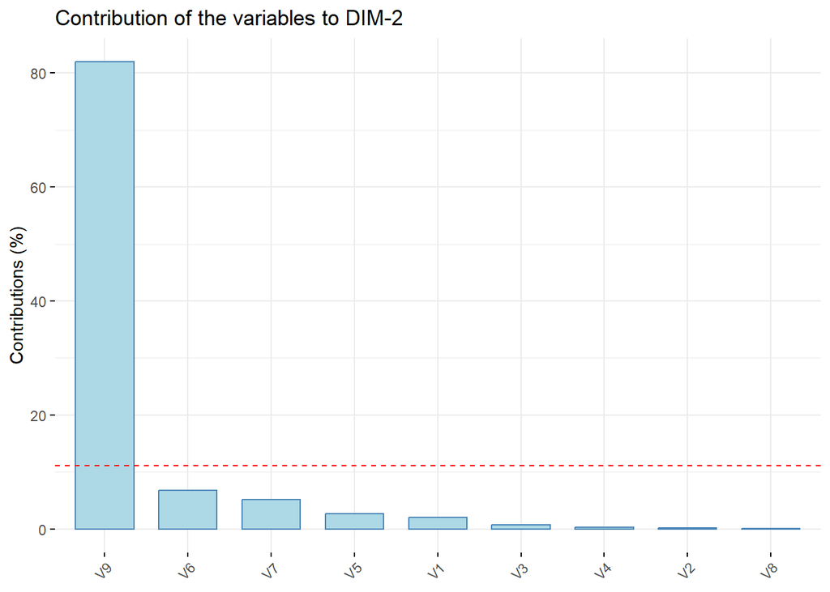

```r
contrib_plot_dim2 <- fviz_contrib(biopsy_PCA,
                              choice = "var",
                              axes = 2,
                              fill = "lightblue")

contrib_plot_dim2 +
  ggtitle("Contribution of the variables to DIM-2") +
  ylab("Contributions (%)")
```

### Variables loading

The **‘variable loadings’** indicates how **each original variable influences the principal components. The loadings show how important each variable is for each component**, helping to understand how the principal components are formed and which variables are most relevant in explaining the variability of the data.

We can see how the variables **V2** and **V3** have a very close and strong relationship with PC1 (principal component 1), while **V9** is clearly more associated with PC2.

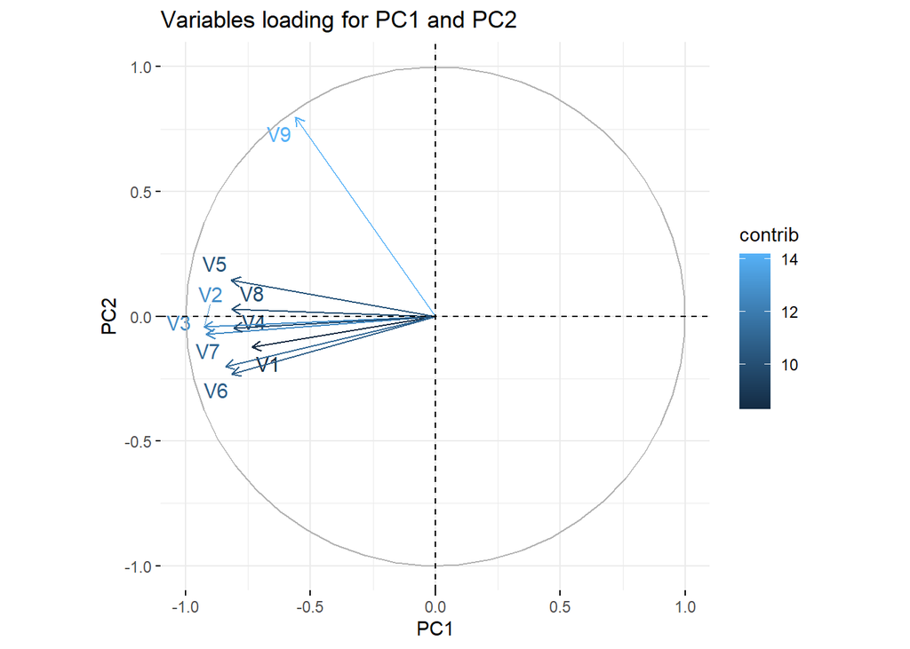

```r
fviz_pca_var(biopsy_PCA, col.var = "contrib", repel = TRUE, axes = c(1, 2)) +
labs(title="Variables loading for PC1 and PC2", x="PC1", y="PC2")
```

### BIPLOT

A biplot is a graph that combines the representation of observations and variables in the same space, typically in the context of Principal Component Analysis (PCA). **Observations** are represented as points on the plot, showing how the data are distributed based on the principal components. **Variables** are represented as arrows or vectors, indicating the direction and magnitude of their influence on the principal components.

In this case, we represent the observations of the **‘class’** variable, which in the **biopsy_PCA** dataframe contains information about the **tumor classification** (**‘benign’** or **‘malignant’**). To facilitate the visualization of the result in the biplot, it is also possible to use different colors to indicate the ‘benign’ and ‘malignant’ categories.

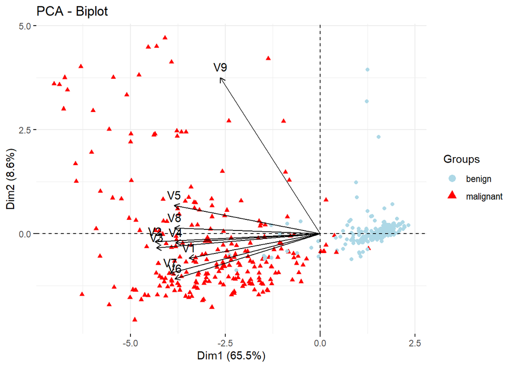

```r
fviz_pca_biplot(biopsy_PCA,
                label = "var",
                habillage = biopsy$class,
                axes = c(1,2),
                addEllipse = FALSE,
                col.var = "black") +
                scale_color_manual(values = c("lightblue", "red"))
```

# Conclusions

We started with a dataframe containing data from 9 variables (V1 to V9) corresponding to samples obtained from breast tumor tissue biopsies.

# Appendix

### MASS::biopsy

The dataset includes the following variables:

**ID**: Sample identifier.  
**V1** (clump thickness): Thickness of the cell clump.  
**V2** (uniformity of cell size): Uniformity of cell size.  
**V3** (uniformity of cell shape): Uniformity of cell shape.  
**V4** (marginal adhesion): Marginal adhesion.  
**V5** (single epithelial cell size): Size of individual epithelial cells.  
**V6** (bare nuclei): Presence of bare nuclei.  
**V7** (bland chromatin): Bland chromatin.  
**V8** (normal nucleoli): Normal nucleoli.  
**V9** (mitoses): Number of mitoses.  
**class**: Tumor classification, which can be “benign” or “malignant”.

### corrplot

The **corrplot** library is a specialized tool for intuitively and attractively visualizing correlation matrices. It facilitates the interpretation of relationships between variables by providing a variety of correlation plots, such as: **Correlation Diagrams** (Displays the correlation matrix with colors and labels representing the strength and direction of correlations between pairs of variables), **Heatmaps** (Uses colors to visualize the magnitude of correlations, making it easier to identify patterns), among others.

### factoextra

The **factoextra** library in R is designed to facilitate the visualization and interpretation of multivariate analysis results, such as Principal Component Analysis (PCA) and Factor Analysis. It includes several useful functions for these tasks: **fviz_pca_biplot** (generates biplots to visualize both observations and variables in the principal component space), **fviz_pca_var** (shows how variables contribute to the principal components), **fviz_pca_ind** (visualizes the distribution of observations in the reduced principal component space), **fviz_eig** (displays a plot of eigenvalues to represent the proportion of variance explained by each component), among others.

### gridExtra

**gridExtra** is an R library that extends the visualization capabilities of the grid graphics system, allowing for flexible combination of multiple plots and tables into a single figure. It provides functions such as **grid.table()** to include tables within plots. It is particularly useful for creating complex compositions of graphs and tables, facilitating the presentation of results in a single visual space.